# Highlight figures

## Figure 1

Figure 1 maps the number of Airbnb Listings and the median Airbnb listing price on the Greater Boston Area (Boston and Cambridge) map. We can see in the first subfigure that places that are far away from downtown are more likely to have more listings. However, from the second subfigure, we see that places near downtown can have very high median listing price.

[figure not shown]

## Figure 2

[figure not shown]

```python
import pandas as pd
import seaborn as sns
import matplotlib.pyplot as plt
import numpy as np
%matplotlib inline
```

```python
def knn_binning(x_values, y_values, num_bins = 40, logged = True):
    max_degree = max(x_values)
    min_degree = min(x_values)

    if logged:
        lower_bound = np.log10(min_degree) if min_degree >= 0.001 else 0.0
        upper_bound = np.log10(max_degree+0.001)
        bins = np.logspace(lower_bound,upper_bound,num_bins, base=10)
    else:
        bins = np.linspace(min_degree,max_degree+0.001,num_bins)

    start = bins[:-1]
    end = bins[1:]
    center = start + (end-start)*0.5


    knn_k = dict((k,0.0) for k in range(len(center)))
    counts = dict((k,0.0) for k in range(len(center)))

    for i in range(len(x_values)):
        x = x_values[i]
        index = np.argmax((x>=start) & (x<end))
        c = center[index]
        knn_k[index] += y_values[i]
        counts[index] += 1

    x = []
    y = []
    for k,v in list(counts.items()):
        if v != 0:
            y.append(knn_k[k]/counts[k])
            x.append(center[k])

    return x,y
```

## Load Data

```python
listing_boston = pd.read_csv("Airbnb/listings_summary_boston.csv")
listing_boston_raw = pd.read_csv("Airbnb/listings_boston.csv")
calendar_boston = pd.read_csv("Airbnb/calendar_boston.csv")
reviews_boston = pd.read_csv("Airbnb/reviews_boston.csv")
```

```python
listing_cambridge = pd.read_csv("Airbnb/listings_summary_cambridge.csv")
listing_cambridge_raw = pd.read_csv("Airbnb/listings_cambridge.csv")
calendar_cambridge = pd.read_csv("Airbnb/calendar_cambridge.csv")
reviews_cambridge = pd.read_csv("Airbnb/reviews_cambridge.csv")
```

```python
# Merge last scraped
listing_cambridge["last_scraped"] = [list(listing_cambridge_raw[listing_cambridge_raw["id"] == listing_id]["last_scraped"])[0] for listing_id in listing_cambridge["id"]]
listing_boston["last_scraped"] = [list(listing_boston_raw[listing_boston_raw["id"] == listing_id]["last_scraped"])[0] for listing_id in listing_boston["id"]]
```

# Concat Boston and Cambridge

```python
def get_max_rows(df):
    srape_later = df.groupby('id').last_scraped.transform(max)
    return df[df.last_scraped == srape_later]
```

```python
listing_great_boston = pd.concat([listing_boston, listing_cambridge])
greater_boston_filter = get_max_rows(listing_great_boston)
# greater_boston_filter["price"] = [float(item.replace('$','').replace(',','')) for item in greater_boston_filter["price"]]
```

```python
greater_boston_filter.to_csv("listing_great_boston.csv", index = False)
```

```python
calendar_great_boston = pd.concat([calendar_boston, calendar_cambridge])
calendar_great_boston_filter = calendar_great_boston.drop_duplicates()
price_list = []
for item in calendar_great_boston_filter["price"]:
    try:
        price = float(item.replace('$','').replace(',',''))
    except:
        price = float(price)
    price_list.append(price)
calendar_great_boston_filter["price"] = price_list
```

```python
calendar_great_boston_filter.to_csv("calendar_great_boston.csv", index = False)
```

```python
review_great_boston = pd.concat([reviews_boston, reviews_cambridge])
review_great_boston_filter = review_great_boston.drop_duplicates()
```

```python
review_great_boston_filter.to_csv("review_great_boston.csv", index = False)
```

# Reload data

```python
listing_great_boston = pd.read_csv("listing_great_boston.csv")
calendar_great_boston = pd.read_csv("calendar_great_boston.csv")
review_great_boston = pd.read_csv("review_great_boston.csv")
```

# Filter data

We filter the listings with listing price lower than 10.

```python
listing_great_boston = listing_great_boston[listing_great_boston["price"] > 10]
calendar_great_boston = calendar_great_boston[calendar_great_boston["price"] > 10]
```

# Basic Analysis

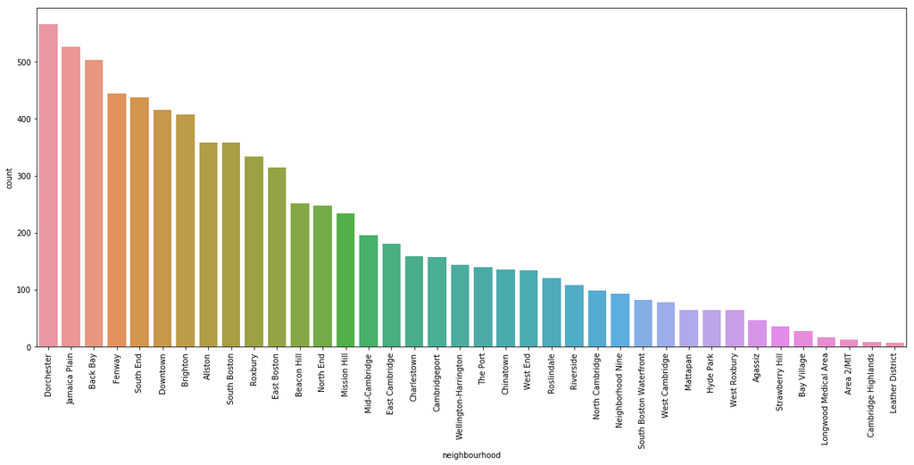

```python
plt.figure(figsize = (20, 8))
sns.countplot(x = "neighbourhood", data = listing_great_boston, order = listing_great_boston['neighbourhood'].value_counts().index)
plt.xticks(rotation = 90);
```

We see Dorchester has most listings, followed by Jamaica Plain and Back Bay. Leather District has the least listings, but this is possibly because the area of Leather District is pretty small.

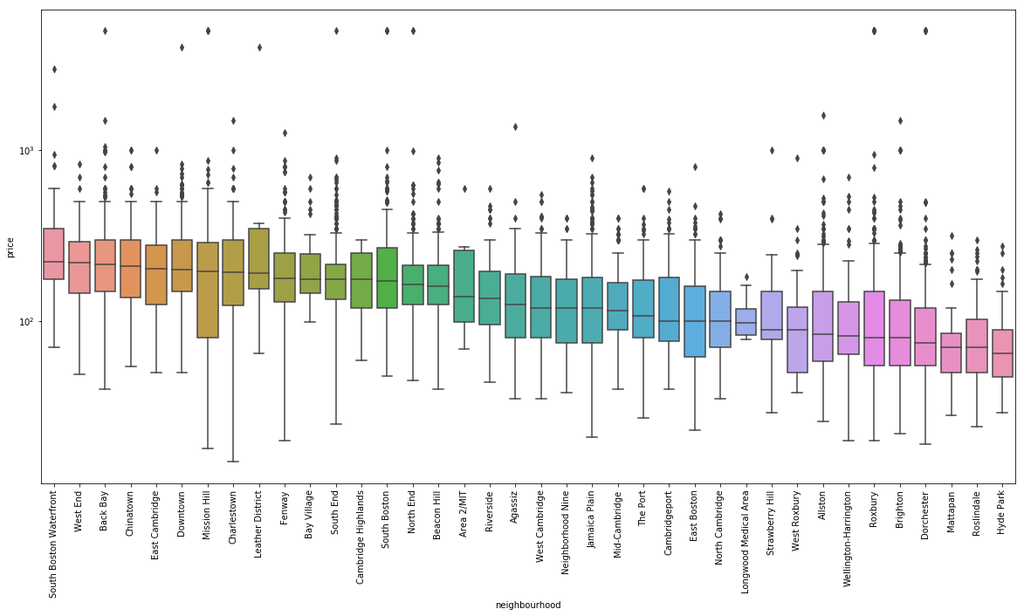

```python
plt.figure(figsize = (20, 10))
order = listing_great_boston.groupby("neighbourhood")["price"].median().fillna(0).sort_values()[::-1].index
sns.boxplot(x = "neighbourhood", y = "price", data = listing_great_boston, order = order)
plt.xticks(rotation = 90)
plt.yscale('symlog')
```

The listing price distribution of neighborhood shows that Waterfront, West End and Back Bay has the highest average listing price, which is reasonable because those areas are known to be expensive in housing. We see that Dorchester, which has the most listings, are among the area with low average listing price.

# Important Charateristics to Attract Reservations

It is pretty important to know what characteristics will attract more reservations. Since we don't have exact reservation data, we use number of reviews as a proxy to evaluate the hotness of the place.

```python
# Filter out the listings that lack reviews per month information
listing_great_boston_review_filter = listing_great_boston.dropna(subset = ["reviews_per_month"])
```

## Hotness related to neighborhood

```
(0, 20)
```

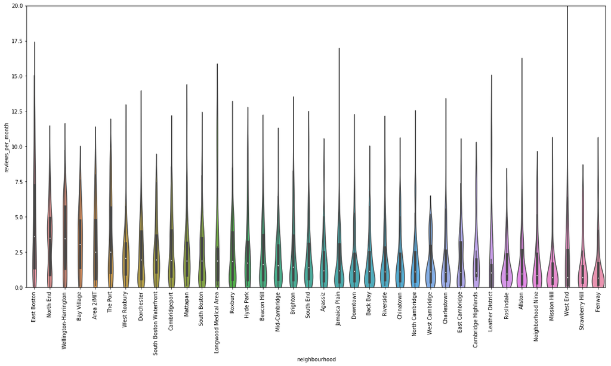

```python
plt.figure(figsize = (20, 10))
order = listing_great_boston_review_filter.groupby("neighbourhood")["reviews_per_month"].median().fillna(0).sort_values()[::-1].index
sns.violinplot(x = "neighbourhood", y = "reviews_per_month", data = listing_great_boston_review_filter, order = order)
plt.xticks(rotation = 90);
plt.ylim(0, 20)
```

We see that the range of review per month is not very high, comparing different regions, East Boston, North End and Wellington-Harrington has the highest average review per month, Fenway, Straberry Hill and West end has the lowest average, but we notice that there are a lot of "outliers" for each area. Therefore, neighbourhood is probably not a good indicator of hotness.

## Room type

```
(0, 20)
```

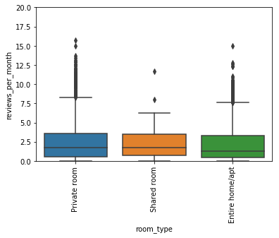

```python
order = listing_great_boston_review_filter.groupby("room_type")["reviews_per_month"].median().fillna(0).sort_values()[::-1].index
sns.boxplot(x = "room_type", y = "reviews_per_month", data = listing_great_boston_review_filter, order = order)
plt.xticks(rotation = 90);
plt.ylim(0, 20)
```

Looking at room type, we see entire home/apt has the lowest average reviews per month. This is probably due to the fact that entire home/apt are more expensive.

## Price

```
Text(0,0.5,'reviews_per_month')
```

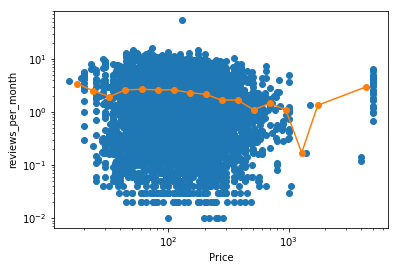

```python
x, y = knn_binning(list(listing_great_boston_review_filter["price"]), list(listing_great_boston_review_filter["reviews_per_month"]), num_bins = 20, logged = True)
plt.loglog(listing_great_boston_review_filter["price"], listing_great_boston_review_filter["reviews_per_month"],'o')
plt.plot(x, y, 'o-')
plt.xlabel("Price")
plt.ylabel("reviews_per_month")
```

Looking at the price, we can observe a slight decaying line of reviews per month as the price goes up. Notice at the very high end when the price exceeds 1,000, there is a increasing, but there are two few listings to make it significant.

## Host listing count

[output not shown]

```
Text(0,0.5,'reviews_per_month')
```

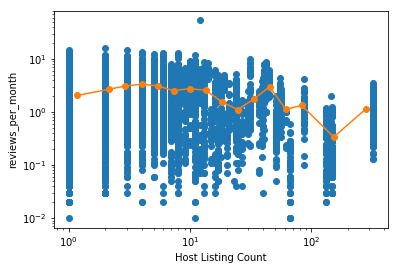

```python
x, y = knn_binning(list(listing_great_boston_review_filter["calculated_host_listings_count"]), list(listing_great_boston_review_filter["reviews_per_month"]), num_bins = 20, logged = True)
plt.loglog(listing_great_boston_review_filter["calculated_host_listings_count"], listing_great_boston_review_filter["reviews_per_month"],'o')
plt.plot(x, y,'o-')
plt.xlabel("Host Listing Count")
plt.ylabel("reviews_per_month")
```

The expericeny of a host might influence the hotness of their listings as well. When we investigate the host listing count agains the review per month, we see that there is a slightly increasing and then decreasing as the listing count increases. This is maybe due to that when the host has more listings, but not too many, they have more energy to devote in it and might get more reviews; but when they have too many listings, they might be too busy to take care of all the listings so the number of reviews goes down.

# Availability analysis

Besides looking at the reviews, availability can be a proxy to show the hotness as well. Though not a perfect proxy because a listing coule be unavailable due to other reasons other than booked.

## Avalability days with neighbourhood

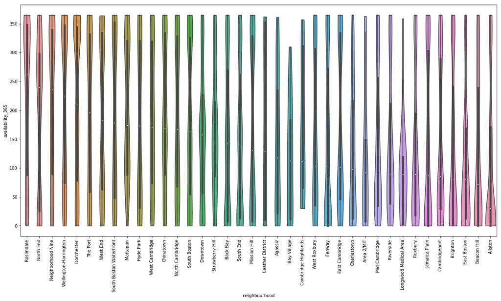

```python
plt.figure(figsize = (20, 10))
order = listing_great_boston.groupby("neighbourhood")["availability_365"].median().fillna(0).sort_values()[::-1].index
sns.violinplot(x = "neighbourhood", y = "availability_365", data = listing_great_boston, order = order, cut = 0)
plt.xticks(rotation = 90);
```

From the violinplot we can see that for most neighbourhood, the distribution is kind of bimodal, one mode on the lower end and one mode on the higher end. We see that on average, listing Roslindale has the highest available days, indicating the reservation rate is probably not that high and Allston has the lowest available days.

## avalability with price

```
Text(0,0.5,'Available Days')
```

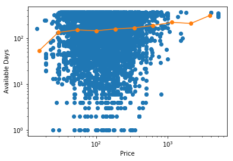

```python
x, y = knn_binning(list(listing_great_boston["price"]), list(listing_great_boston["availability_365"]), num_bins = 15, logged = True)
plt.loglog(listing_great_boston["price"], listing_great_boston["availability_365"],'o')
plt.plot(x, y, 'o-')
plt.xlabel("Price")
plt.ylabel("Available Days")
```

Here we see that as the price goes up, avalability increases, which might indicate expensive listing are less booked

## Avalability with room type

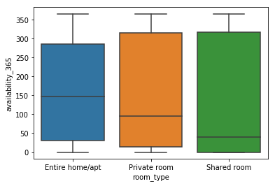

```python
sns.boxplot(x = "room_type", y = "availability_365", data = listing_great_boston)
```

Here we see that the availability ranking is entire home/apt, private room and shared room. This might be due to the price as well.

## Available days with number of listings of the host

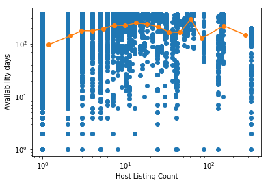

```python
x, y = knn_binning(list(listing_great_boston["calculated_host_listings_count"]), list(listing_great_boston["availability_365"]), num_bins = 20, logged = True)
plt.loglog(listing_great_boston["calculated_host_listings_count"], listing_great_boston["availability_365"],'o')
plt.plot(x, y,'o-')
plt.xlabel("Host Listing Count")
plt.ylabel("Availability days");
```

Indicating by the average line, seems as the listing count increase, available days goes up slightly and then slightly goes down.

# Airbnb, Geospatial, and Analyze Boston Data

With neighbourhood data, Airbnb data is naturally geospatial, therefore it will be good to visualize them on a map. Additionally, Airbnb data can also show some underlying patterns about the cities, and together with Analyze Boston data, we might be able to discover some interesting phenomena.

## Load Analyze Boston data and merge with Airbnb data

```python
race = pd.read_csv("Airbnb/race-and-or-ethnicity.csv")
race_recent = race[(race["Decade"] == 2010) & (race["Race and or Ethnicity"] == "Black/ African American")]
```

```python
race_2010 = race[(race["Decade"] == 2010)]
neighborhood_list = []
population_list = []
for neighborhood in set(race_2010["Neighborhood"]):
    subset = list(race_2010[race_2010["Neighborhood"] == neighborhood]["Number of People"])
    neighborhood_list.append(neighborhood)
    population_list.append(sum(subset))
population_df = pd.DataFrame()
population_df["Neighborhood"] = neighborhood_list
population_df["Population"] = population_list
```

```python
housing_tenure = pd.read_csv("Airbnb/housing-tenure.csv")
housing_recent = housing_tenure[(housing_tenure["Decade"] == 2010) & (housing_tenure["Unit Type"] == "Owner-occupied")]
```

```python
new_list = []
for item in list(housing_recent["Percent of Population"]):
    try:
        new_list.append(float(item.replace('%','')))
    except:
        nex_list.append(item)
housing_recent["Percent of Population"] = new_list
```

```python
neighbourhood = listing_great_boston.groupby("neighbourhood")
neighbourhood_list_count = neighbourhood.count()
neighbourhood_list_avg_price = neighbourhood.price.median()
neighbourhood_review_per_month = neighbourhood.reviews_per_month.median()
neighbourhood_availability = neighbourhood.availability_365.median()
temp_df = pd.DataFrame()
temp_df['neighbourhood'] = neighbourhood_list_count.index
temp_df['count'] = list(neighbourhood_list_count["id"])
temp_df['avg_price'] = list(neighbourhood_list_avg_price)
temp_df['avg_review_per_month'] = list(neighbourhood_review_per_month)
temp_df['availability'] = list(neighbourhood_availability)
merged = great_boston.set_index('neighbourhood').join(temp_df.set_index('neighbourhood')).join(race_recent.set_index("Neighborhood")).join(housing_recent.set_index("Neighborhood"), lsuffix='_race', rsuffix='_housing').join(population_df.set_index("Neighborhood"))
```

## Geospatial Visualization

```python
from shapely.geometry import Point, Polygon
```

```python
import geopandas as gpd
boston = gpd.read_file('Airbnb/boston.geojson')
cambridge = gpd.read_file('Airbnb/cambridge.geojson')
great_boston = pd.concat([boston, cambridge])
```

```
Text(0.5,1,'Number of Airbnb Listing of Greater Boston Area')
```

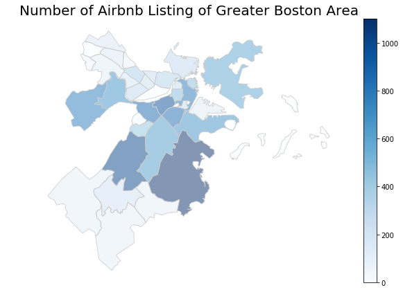

```python
# set a variable that will call whatever column we want to visualise on the map
variable = 'count'
# set the range for the choropleth
vmin, vmax = 0, 1100
# create figure and axes for Matplotlib
fig, ax = plt.subplots(1, figsize=(10, 7))
merged.plot(column=variable, cmap='Blues', linewidth=0.8, ax=ax, edgecolor='0.8')
ax.axis('off')
sm = plt.cm.ScalarMappable(cmap='Blues', norm=plt.Normalize(vmin=vmin, vmax=vmax))
sm._A = []
cbar = fig.colorbar(sm)
ax.set_title('Number of Airbnb Listing of Greater Boston Area',fontdict={'fontsize': '20', 'fontweight' : '3'})
```

```
Text(0.5,1,'Median Airbnb Listing Price of Greater Boston Area')
```

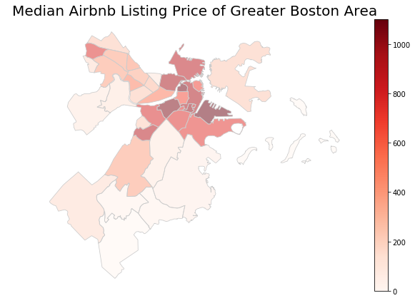

```python
# set a variable that will call whatever column we want to visualise on the map
variable = 'avg_price'
# set the range for the choropleth
vmin, vmax = 0, 1100
# create figure and axes for Matplotlib
fig, ax = plt.subplots(1, figsize=(10, 7))
merged.plot(column=variable, cmap='Reds', linewidth=0.8, ax=ax, edgecolor='0.8')
ax.axis('off')
sm = plt.cm.ScalarMappable(cmap='Reds', norm=plt.Normalize(vmin=vmin, vmax=vmax))
sm._A = []
cbar = fig.colorbar(sm)
ax.set_title('Median Airbnb Listing Price of Greater Boston Area',fontdict={'fontsize': '20', 'fontweight' : '3'})
```

```
Text(0.5,1,'Median Airbnb Reviews per Month of Greater Boston Area')
```

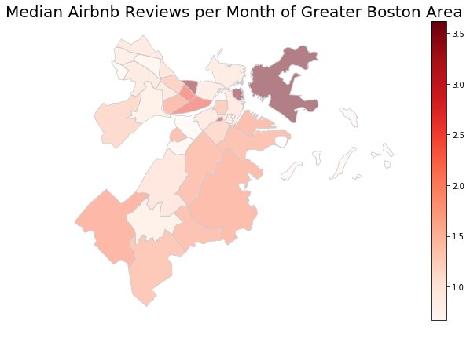

```python
# set a variable that will call whatever column we want to visualise on the map
variable = 'avg_review_per_month'
# set the range for the choropleth
vmin, vmax = min(neighbourhood_review_per_month), max(neighbourhood_review_per_month)
# create figure and axes for Matplotlib
fig, ax = plt.subplots(1, figsize=(10, 7))
merged.plot(column=variable, cmap='Reds', linewidth=0.8, ax=ax, edgecolor='0.8')
ax.axis('off')
sm = plt.cm.ScalarMappable(cmap='Reds', norm=plt.Normalize(vmin=vmin, vmax=vmax))
sm._A = []
cbar = fig.colorbar(sm)
ax.set_title('Median Airbnb Reviews per Month of Greater Boston Area',fontdict={'fontsize': '20', 'fontweight' : '3'})
```

## Airbnb + Analyze Boston

### Population against count, avg_price and avg_review_per_month

```
Text(0.5,0,'Population')
```

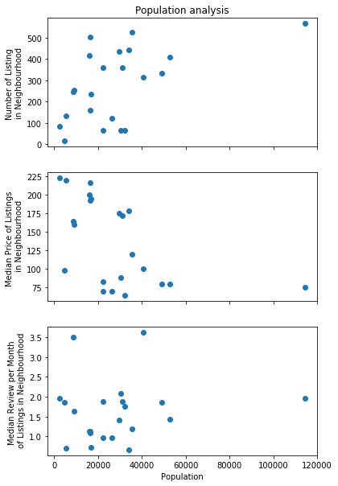

```python
f, axarr = plt.subplots(3, sharex=True, figsize = (6, 10))
axarr[0].plot(merged["Population"],merged["count"],'o')
axarr[0].set_title('Population analysis')
axarr[0].set_ylabel('Number of Listing \nin Neighbourhood')
axarr[1].plot(merged["Population"],merged["avg_price"],'o')
axarr[1].set_ylabel('Median Price of Listings \n in Neighbourhood')
axarr[2].plot(merged["Population"],merged["avg_review_per_month"],'o')
axarr[2].set_ylabel('Median Review per Month \n of Listings in Neighbourhood')
axarr[2].set_xlabel('Population')
```

### Black/African American population percent against count, avg_price and avg_review_per_month

```
Text(0.5,0,'Black/African American population percent')
```

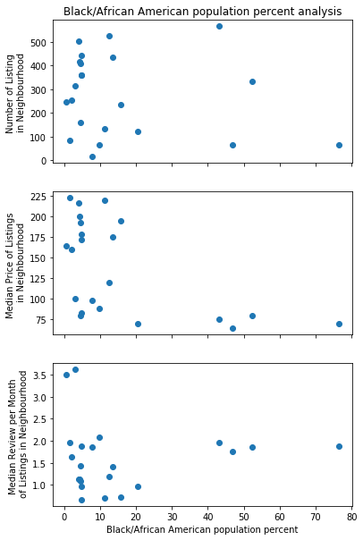

```python
f, axarr = plt.subplots(3, sharex=True, figsize = (6, 10))
axarr[0].plot(merged["Percent of Population_race"],merged["count"],'o')
axarr[0].set_title('Black/African American population percent analysis')
axarr[0].set_ylabel('Number of Listing \nin Neighbourhood')
axarr[1].plot(merged["Percent of Population_race"],merged["avg_price"],'o')
axarr[1].set_ylabel('Median Price of Listings \n in Neighbourhood')
axarr[2].plot(merged["Percent of Population_race"],merged["avg_review_per_month"],'o')
axarr[2].set_ylabel('Median Review per Month \n of Listings in Neighbourhood')
axarr[2].set_xlabel('Black/African American population percent')
```

### Owner-occupied housing percent against count, avg_price and avg_review_per_month

```
Text(0.5,0,'Owner-occupied housing percent')
```

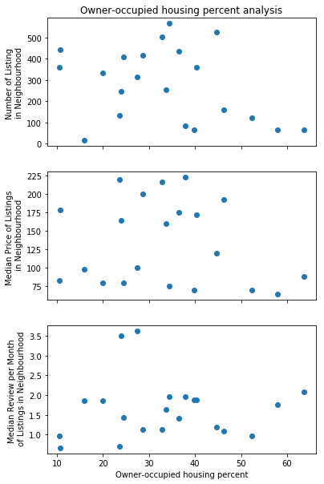

```python
f, axarr = plt.subplots(3, sharex=True, figsize = (6, 10))
axarr[0].plot(merged["Percent of Population_housing"],merged["count"],'o')
axarr[0].set_title('Owner-occupied housing percent analysis')
axarr[0].set_ylabel('Number of Listing \nin Neighbourhood')
axarr[1].plot(merged["Percent of Population_housing"],merged["avg_price"],'o')
axarr[1].set_ylabel('Median Price of Listings \n in Neighbourhood')
axarr[2].plot(merged["Percent of Population_housing"],merged["avg_review_per_month"],'o')
axarr[2].set_ylabel('Median Review per Month \n of Listings in Neighbourhood')
axarr[2].set_xlabel('Owner-occupied housing percent')
```

# Plan

- Add data on public transportaion
- Add data on tourism places
- Build a model predicting (fitting) number of reviews or availability
- and more!

# Price stablility

```python
one_example = calendar_great_boston_filter[calendar_great_boston_filter["listing_id"] ==
                                           list(calendar_great_boston_filter["listing_id"])[9]]
one_example["date"] = pd.to_datetime(one_example["date"])
plt.figure(figsize = (20, 10))
plt.plot(one_example["date"], one_example["price"])
plt.xticks(rotation = 90);
```

[output not shown]